# final_tutorial

Evolution of the Quarterback Position in American Football

Derek Miller

Motivation and Importance

The sport of football is very much engrained and deeply rooted in American culture. It has become part of the country's identity, dominating television ratings every Sunday from September to February. The sport is a source of entertainment for millions of Americans, either through watching, playing, coaching, betting, etc. The National Football League (NFL) is the world's most popular (American) football league and [is a multi-billion dollar business](https://www.sportico.com/leagues/football/2023/nfl-revenue-whats-next-1234708609/), showcasing just how much of an economic impact the sports industry has. Not only is it popular professionally, but many universities around the United States support having football teams. Football teams have provided numerous benefits to universities that have them, including:

- Increase in Revenue -> Through ticket sales, merchandise sales, and television contracts
- Improved Visibility -> Having a football team puts universities on the map. Many prospective students hear first of a universities football team before really knowing much about the school itself
- Community / Social Life -> Brings together students and alumni, is a source of social entertainment for students
- Recruiting -> Having a good football team may attract other high prospect athletes for other sports, improving the sports program for a university as a whole.

Likewise, professtional sports are also very impactful, and listed below are some reasons why the National Football League (NFL) is important:

- Entermainment -> the NFL provides entertainment to millions of fans not only in the USA, but around the world. The league has expanded massively in the recent decades, and now games are even played in other countries, like the United Kingdom, Mexico, and Germany.
- Economic -> As stated above, the NFL is a multi-billion dollar business, but it has a significant impact on the job market. Not only do high-level atheletes and coaches get jobs, but there's also a countless amount of other jobs are created/ impacted like:
  - medical staff/trainers, nutritionists
  - sports writers/reporters/media staff
  - advertisers/marketers
  - restuarant owners and employees
  - tourism and hotel industry
  - construction industry

The sports teams bring in a massive amount of revenue for revenue for their city and state, impacting the entire community economically and culturally.

- Community -> NFL teams are actively involved in the city they're located, whether it's through different community events, outreach programs, and charity work. For instance, NFL Play-60 is a program for kids that encourages kids to be active for at least 60 minutes a day. Kids can go to these camps, meet their favorite sports players, and go have fun.

#### How the Game is Played

American football is a game played between two teams. Each team has an offensive group of players and a defensive group of players. First, one team's offense tries to score against the opposing team's defense. Then, the other team's offense tries to scrore against the opposing team's defense. The teams' take turns going back and forth on offense and defense, respectively, until time runs out. Once time runs out, the team with the most points scored wins.

The game is played on a football field, which is 100 yards long and 53.3 yards wide. Below is an image of a football field. To score, teams must drive the ball down the field and get the ball in the opposing teams endzone (Endzones are represented by the dark green squares at opposite sides of the field in the image below). When I say "drive", I mean the teams offense must run a certain number of successful plays (or strategic moves, like a game of Chess) the move the ball downfield against the opposing teams defense. If the defense is able to stop the offense after a certain number of plays, then a change of possession occurs and now the other team gets the ball and in turn a chance to score points. If the offense scores, then a change of possesion still occurs, as the scoring team then kicks the ball downfield and the other team receives the ball, signaling a change of possession. Additionally, a play stops when the ball carrier is tackled to the ground.

[figure not shown]

There are other ways to score, along with other aspects of the game not mentioned. However, we'll omit those details for now as we're mainly concerned with the quarterback position of the game.

#### The Quarterback Position

Often times the most important position in American football is the quarterback. The quarterback on a football team is like the conductor of an orchestra. They're responsible for directing the offense, relaying in plays to run, understanding everyone's roll on the field, reading the opposing defense and make adjustments accordingly, and serving as the overall leader and face of the team. Quarterbacks are so important because once the play starts, they are in charge of getting the ball to the necessary player. Every play depends on the quarterback first doing their job. With the ball, the quarterback can either throw the ball, hand the ball off to another player, or run with it themselves.

Quarterbacks are typically the most recognizable player on a football field, and are widely considered the [single most important position](https://www.nfl.com/news/ranking-each-position-s-importance-from-quarterback-to-returner-0ap3000000503855#:~:text=1\)%20Quarterback&text=The%20quarterback%20is%20not%20only,the%20end%20of%20the%20season.) when deciding the outcome of a game. Thus, when studying how the game has changed over time, it it necessary to see how the quarterback position has evolved. In turn, understanding the history of the quarterback position will give coaches better insight into the current trends and patterns, leading to better developed game plans, strategies and techniques to improve performance both when facing against quarterbacks on defense and using them on offense.

This tutorial will analyze the quarterback position (NFL) by going through the Data Science Lifecycle:

1. Data Collection
2. Data Processing
3. Exploratory Analysis & Data Visualization
4. Model: Analysis, Hypothesis Testing, & ML
5. Interpretation: Insight & Policy Decision </p>

### Data Collection

The data being collected and analyzed is from [Pro Football Reference](https://www.pro-football-reference.com/). Pro Football Reference provides statistical data, analysis, and historical information in tabular format for various different football leagues (NFL, College, Canadian, etc.). We'll just be focusing on their passing data for NFL quarterbacks from 1932 to 2022. While the NFL started about a decade prior to 1932, passing/rushing statistics were not kept until 1932. We'll be looking for certain quarterback statistics to analyze by year, and for a players career. These include:

- Passing Yards -> Quarterbacks can throw the ball. This is how many yards a quarterback throws for a season (this includes yards after the receiver catches and runs with the ball)
- Passing Touchdowns -> When a quarterback throws the ball to another player, and that player scores (reaches the endzone), this is called a passing touchdown
- Passing Touchdown % -> What percent of passes thrown result in Touchdowns
- Completion Percentage -> This is calculated by finding (balls caught by player on the same team) / (total nummber of balls thrown by the quarterback)
- Attempts -> How many times a quarterback attempted to throw the ball
- Interceptions -> How many times was the ball thrown and caught by the other team, resulting in a change of possession.
- Interception % -> What percent of passes thrown result in interceptions
- Average Yards per Attempt -> How many yards is a completion, on average
- Average Yards per Game -> How many passing yards per game does the quarterback have.
- Sacks -> How many times was the quarterback tackled before they threw the ball out.
- Sack % -> How many times is the quarterback sacked in relation to the amount of times they attempt a pass.
- Net Yards Gained Per Pass Attempt -> This advanced metric takes into account Sacks
- Adjusted Net Yards Per Pass Attemp -> This advanced metric takes into account Sacks, Touchdowns, and Interceptions
- Passer Rating -> This advanced metric is calculated from a mathematical formula that takes in other quarterback statistics as variables. This statistics attempts to gauge how well the quarterback is playing overall.
- Fourth Quarter Comebacks -> How many times has the quarterback led their team to win the game in the final 15 minutes.
- Game Winning Drives -> How many times has the quarterback led their team to win the game on the final possession of the game.
- Rushing Yards -> How many rushing yards does the quarterback have.
- Rushing Touchdowns -> How many rushing touchdowns does the quarterback have.

Now, before we dive into scraping, let's import the necessary Python libraries and packages for this tutorial.

```python
# Necessary for Data Collection
from selenium import webdriver
from selenium.webdriver.chrome.options import Options
from selenium.webdriver.common.by import By
from selenium.common.exceptions import NoSuchElementException
from selenium.common.exceptions import ElementClickInterceptedException
from bs4 import BeautifulSoup
import time

# Necessary for Data Collection & Processing
import pandas as pd
import numpy as np

# Necesscary for Exploratory Analysis and Data Visualization
import matplotlib.pyplot as plt
import seaborn as sns

# Necessary for Model: Analysis, Hypothesis Testing, and ML
import statsmodels.formula.api as sm
from sklearn.linear_model import LinearRegression
from sklearn.ensemble import RandomForestClassifier
```

#### Extract Quarterback statistics, by Year (1932 - 2022)

First, we use Selenium, BeautifulSoup, and Pandas to read data from Pro Football Reference and store the necessary tabular data in a DataFrame object. We first start at the year 1932, extract and store the data, then automatically click the "Next Season" button until we've reached the most recent season, the 2022 season. Here, we're extracting statistics (like some of the ones mentioned) that'll help determine quarterback performance over time.

The comments in the code below explain step by step what the code is doing. I will provide a brief overview here. For each year (1932 to 2022), a webpage exists containing tabular data for every player that threw a pass for a certain year, and a webpage exists containing tabular data for every player that ran the ball for a certain year. We start at the webpage for 1932. After extracting and storing the passing data for a certain year in our DataFrame, we will click the "Next Season" button on the webpage, then repeat the data extraction steps for 1933. We do this for every next webpage until we get to the webpage representing the 2022 season. At this point, after extracting and storing the data for the 2022 season, there's no more seasons to extract data from, and so we stop. We will do the same for rushing statistics, starting at the webpage reprsenting 1932 rushing statistics and extracting data all the way up to the 2022 season. Note that while scraping, some pop-ups may occur. The code below handles this edge case by closing pop-ups when they appear. We will store these passing and rushing statistics in two separate DataFrame objects called 'df_passing' and 'df_rushing', respectively.

#### IMPORTANT NOTE about Running Code:

Currently, the extraction process mentioned above takes approximately 7 minutes for passing and rushing statistics each. Thus, I have just demonstrated that the code works for a small subset of data, specifically from 2017 to 2022. Thus, in the example down below I start at 2017 instead of 1932.

If you want to extract data all the data (1932-2022), then follow the steps down below:

- STEP #1 -> Change... driver.get("https://www.pro-football-reference.com/years/2017/passing.htm")

  ```
         to... driver.get("https://www.pro-football-reference.com/years/1932/passing.htm")
  ```

  - Now we're extracting passing statistics from 1932 to present, which is the size of the full dataset we want
- STEP #2 -> Change... i = 2017 to... i = 1932
  - Here, we adjust the iterator to represent the desired start year, so break from the loop will occur after (2022 - 1932) iterations

```python
# Create instance of a Chrome web driver
driver = webdriver.Chrome()

# Call 'get()' method to open a URL in the browser window
driver.get("https://www.pro-football-reference.com/years/2017/passing.htm")

# Try to extract the data
try:
    # Create an empty DataFrame to store the data
    df_passing = pd.DataFrame()

    # Initialize start year
    i = 2017

    # Loop through / Extract data for each NFL season
    while i != 2023:
        # Wait some time in order to properly load each page
        time.sleep(3)

        # Use Beautiful Soup to extract the data from the table
        soup = BeautifulSoup(driver.page_source, 'html.parser')
        # Find all HTML 'table' tags, we only want the first one (thus index 0)
        table = soup.find_all('table')[0]
        # Store the desired table's contents into a new DataFrame object
        temp_df = pd.read_html(str(table))[0]
        # Add a column called 'year' to the DataFrame
        temp_df['year'] = i

        # Concatenate the DataFrame for the current year to the preexisting DataFrame
        # that stores information for all the years (we're continuosly building 'df'
        # from scratch)
        df_passing = pd.concat([df_passing, temp_df], ignore_index=True)

        # Increment the current year by 1, break once we reached the most recent season
        i += 1
        if i == 2023:
            break

        # Find the 'Next Season' button on the current webpage, if it exists
        try:
            next_button = driver.find_element("link text", "Next Season")
            next_button.click()

        # If it doesn't exist in that we get a Pop-Up, close that Pop-Up and proceed
        # to clicking 'Next Season'.
        except (NoSuchElementException, ElementClickInterceptedException):
            try:
                close_button = driver.find_element("class name", "closer")
                close_button.click()
                next_button = driver.find_element("link text", "Next Season")
                next_button.click()
            except NoSuchElementException:
                pass
    # Close the Web Driver once we're done extracting data from the current page
    driver.close()

    # View the final DataFrame
    df_passing.to_csv('nfl_passing_sample.csv', index=False)
except:
    # Close the Web Driver just in case any errors occur
    driver.close()
    raise
```

```python
# Create instance of a Chrome web driver
driver = webdriver.Chrome()

# Call 'get()' method to open a URL in the browser window
driver.get("https://www.pro-football-reference.com/years/2017/rushing.htm")

# Try to extract the data
try:
    # Create an empty DataFrame to store the data
    df_rushing = pd.DataFrame()

    # Initialize start year
    i = 2017

    # Loop through / Extract data for each NFL season
    while i != 2023:
        # Wait some time in order to properly load each page
        time.sleep(3)

        # Use Beautiful Soup to extract the data from the table
        soup = BeautifulSoup(driver.page_source, 'html.parser')
        # Find all HTML 'table' tags, we only want the first one (thus index 0)
        table = soup.find_all('table')[0]
        # Store the desired table's contents into a new DataFrame object
        temp_df = pd.read_html(str(table))[0]
        # Add a column called 'year' to the DataFrame
        temp_df['year'] = i

        # Concatenate the DataFrame for the current year to the preexisting DataFrame
        # that stores information for all the years (we're continuosly building 'df'
        # from scratch)
        df_rushing = pd.concat([df_rushing, temp_df], ignore_index=True)

        # Increment the current year by 1, break once we reached the most recent season
        i += 1
        if i == 2023:
            break

        # Find the 'Next Season' button on the current webpage, if it exists
        try:
            next_button = driver.find_element("link text", "Next Season")
            next_button.click()

        # If it doesn't exist in that we get a Pop-Up, close that Pop-Up and proceed
        # to clicking 'Next Season'.
        except (NoSuchElementException, ElementClickInterceptedException):
            try:
                close_button = driver.find_element("class name", "closer")
                close_button.click()
                next_button = driver.find_element("link text", "Next Season")
                next_button.click()
            except NoSuchElementException:
                pass
    # Close the Web Driver once we're done extracting data from the current page
    driver.close()

    df_rushing.to_csv('nfl_rushing_sample.csv', index=False)
except:
    # Close the Web Driver just in case any errors occur
    driver.close()
    raise
```

To showcase that the code above properly extracts and collects the data, I will print the resulting DataFrames ('df_passing' and 'df_rushing') down below.

```python
df_passing
```

|  | Rk | Player | Tm | Age | Pos | G | GS | QBrec | Cmp | Att | ... | Rate | QBR | Sk | Yds.1 | Sk% | NY/A | ANY/A | 4QC | GWD | year |
| --- | --- | --- | --- | --- | --- | --- | --- | --- | --- | --- | --- | --- | --- | --- | --- | --- | --- | --- | --- | --- | --- |
| 0 | 1 | Tom Brady*+ | NWE | 40 | QB | 16 | 16 | 13-3-0 | 385 | 581 | ... | 102.8 | 70.6 | 35 | 201 | 5.7 | 7.10 | 7.56 | 2 | 2 | 2017 |
| 1 | 2 | Philip Rivers* | LAC | 36 | QB | 16 | 16 | 9-7-0 | 360 | 575 | ... | 96.0 | 61.1 | 18 | 120 | 3.0 | 7.41 | 7.60 | 2 | 2 | 2017 |
| 2 | 3 | Matthew Stafford | DET | 29 | QB | 16 | 16 | 9-7-0 | 371 | 565 | ... | 99.3 | 65.2 | 47 | 287 | 7.7 | 6.80 | 7.01 | 1 | 4 | 2017 |
| 3 | 4 | Drew Brees* | NOR | 38 | QB | 16 | 16 | 11-5-0 | 386 | 536 | ... | 103.9 | 62.5 | 20 | 145 | 3.6 | 7.53 | 7.71 | 2 | 2 | 2017 |
| 4 | 5 | Ben Roethlisberger* | PIT | 35 | QB | 15 | 15 | 12-3-0 | 360 | 561 | ... | 93.4 | 66.6 | 21 | 139 | 3.6 | 7.07 | 6.95 | 3 | 4 | 2017 |
| ... | ... | ... | ... | ... | ... | ... | ... | ... | ... | ... | ... | ... | ... | ... | ... | ... | ... | ... | ... | ... | ... |
| 648 | 102 | Christian Kirk | JAX | 26 | WR | 17 | 17 | NaN | 0 | 1 | ... | 39.6 | 9.9 | 0 | 0 | 0.0 | 0.00 | 0.00 | NaN | NaN | 2022 |
| 649 | 103 | Cooper Kupp | LAR | 29 | WR | 9 | 9 | NaN | 0 | 1 | ... | 39.6 | 3.0 | 0 | 0 | 0.0 | 0.00 | 0.00 | NaN | NaN | 2022 |
| 650 | 104 | James Proche | BAL | 26 | WR | 15 | 0 | NaN | 0 | 1 | ... | 0.0 | 0.0 | 0 | 0 | 0.0 | 0.00 | -45.00 | NaN | NaN | 2022 |
| 651 | 105 | Tommy Townsend*+ | KAN | 26 | P | 17 | 0 | NaN | 0 | 1 | ... | 39.6 | NaN | 0 | 0 | 0.0 | 0.00 | 0.00 | NaN | NaN | 2022 |
| 652 | 106 | Garrett Wilson | NYJ | 22 | WR | 17 | 12 | NaN | 0 | 1 | ... | 39.6 | 0.8 | 0 | 0 | 0.0 | 0.00 | 0.00 | NaN | NaN | 2022 |

653 rows × 32 columns

```python
df_rushing
```

|  | Unnamed: 0_level_0 Rk | Unnamed: 1_level_0 Player | Unnamed: 2_level_0 Tm | Unnamed: 3_level_0 Age | Unnamed: 4_level_0 Pos | Games G | Games GS | Rushing Att | Rushing Yds | Rushing TD | Rushing 1D | Rushing Lng | Rushing Y/A | Rushing Y/G | Unnamed: 14_level_0 Fmb | year |
| --- | --- | --- | --- | --- | --- | --- | --- | --- | --- | --- | --- | --- | --- | --- | --- | --- |
| 0 | 1 | Le'Veon Bell*+ | PIT | 25 | RB | 15 | 15 | 321 | 1291 | 9 | 71 | 27 | 4.0 | 86.1 | 3 | 2017 |
| 1 | 2 | LeSean McCoy* | BUF | 29 | RB | 16 | 16 | 287 | 1138 | 6 | 57 | 48 | 4.0 | 71.1 | 3 | 2017 |
| 2 | 3 | Melvin Gordon | LAC | 24 | RB | 16 | 16 | 284 | 1105 | 8 | 61 | 87 | 3.9 | 69.1 | 1 | 2017 |
| 3 | 4 | Todd Gurley*+ | LAR | 23 | RB | 15 | 15 | 279 | 1305 | 13 | 69 | 57 | 4.7 | 87.0 | 5 | 2017 |
| 4 | 5 | Jordan Howard | CHI | 23 | RB | 16 | 16 | 276 | 1122 | 9 | 65 | 53 | 4.1 | 70.1 | 1 | 2017 |
| ... | ... | ... | ... | ... | ... | ... | ... | ... | ... | ... | ... | ... | ... | ... | ... | ... |
| 2163 | 362 | Adam Thielen | MIN | 32 | WR | 17 | 17 | 1 | 4 | 0 | 0 | 4 | 4.0 | 0.2 | 0 | 2022 |
| 2164 | 363 | Marquez Valdes-Scantling | KAN | 28 | WR | 17 | 11 | 1 | -3 | 0 | 0 | -3 | -3.0 | -0.2 | 0 | 2022 |
| 2165 | 364 | Jameson Williams | DET | 21 | WR | 6 | 0 | 1 | 40 | 0 | 1 | 40 | 40.0 | 6.7 | 0 | 2022 |
| 2166 | 365 | Cedrick Wilson Jr. | MIA | 27 | WR | 15 | 0 | 1 | 8 | 0 | 0 | 8 | 8.0 | 0.5 | 0 | 2022 |
| 2167 | 366 | Michael Woods II | CLE | 22 | WR | 10 | 0 | 1 | -5 | 0 | 0 | -5 | -5.0 | -0.5 | 0 | 2022 |

2168 rows × 16 columns

### Data Processing

Now we need to clean up our data and tables. Some of the tasks we need to do to clean up our data include:

- Filtering out non-quarterback positions
- Removing certain characters from data entries in certain columns
- Split certain column(s) into multiple columns
- Deal with Null Values

For speeding up the data collection step, below we have just read in the CSVs that we created above. It contains all data from 1932 to 2022.

```python
# Read in the CSVs that were created above
df_passing = pd.read_csv('nfl_passing.csv')
df_rushing = pd.read_csv('nfl_rushing.csv', header=1)
df_passing
```

|  | Rk | Player | Tm | Age | Pos | G | GS | QBrec | Cmp | Att | ... | Sk | Yds.1 | Sk% | NY/A | ANY/A | 4QC | GWD | year | 1D | QBR |
| --- | --- | --- | --- | --- | --- | --- | --- | --- | --- | --- | --- | --- | --- | --- | --- | --- | --- | --- | --- | --- | --- |
| 0 | 1 | Arnie Herber+ | GNB | 22 | TB | 14 | 8 | NaN | 37 | 101 | ... | NaN | NaN | NaN | NaN | NaN | 0 | 0 | 1932 | NaN | NaN |
| 1 | 2 | Walt Holmer | CRD | 30 | NaN | 10 | 4 | NaN | 25 | 78 | ... | NaN | NaN | NaN | NaN | NaN | 0 | 0 | 1932 | NaN | NaN |
| 2 | 3 | Jack McBride | 2TM | 31 | TB | 12 | 6 | NaN | 36 | 74 | ... | NaN | NaN | NaN | NaN | NaN | 0 | 0 | 1932 | NaN | NaN |
| 3 | 4 | Keith Molesworth | CHI | 27 | QB | 14 | 14 | NaN | 25 | 64 | ... | NaN | NaN | NaN | NaN | NaN | 0 | 0 | 1932 | NaN | NaN |
| 4 | 5 | Benny Friedman | BKN | 27 | TB | 11 | 10 | NaN | 23 | 74 | ... | NaN | NaN | NaN | NaN | NaN | 0 | 0 | 1932 | NaN | NaN |
| ... | ... | ... | ... | ... | ... | ... | ... | ... | ... | ... | ... | ... | ... | ... | ... | ... | ... | ... | ... | ... | ... |
| 7841 | 102 | Christian Kirk | JAX | 26 | WR | 17 | 17 | NaN | 0 | 1 | ... | 0 | 0 | 0.0 | 0.00 | 0.00 | NaN | NaN | 2022 | 0 | 9.9 |
| 7842 | 103 | Cooper Kupp | LAR | 29 | WR | 9 | 9 | NaN | 0 | 1 | ... | 0 | 0 | 0.0 | 0.00 | 0.00 | NaN | NaN | 2022 | 0 | 3.0 |
| 7843 | 104 | James Proche | BAL | 26 | WR | 15 | 0 | NaN | 0 | 1 | ... | 0 | 0 | 0.0 | 0.00 | -45.00 | NaN | NaN | 2022 | 0 | 0.0 |
| 7844 | 105 | Tommy Townsend*+ | KAN | 26 | P | 17 | 0 | NaN | 0 | 1 | ... | 0 | 0 | 0.0 | 0.00 | 0.00 | NaN | NaN | 2022 | 0 | NaN |
| 7845 | 106 | Garrett Wilson | NYJ | 22 | WR | 17 | 12 | NaN | 0 | 1 | ... | 0 | 0 | 0.0 | 0.00 | 0.00 | NaN | NaN | 2022 | 0 | 0.8 |

7846 rows × 32 columns

Next up, we'll do some data cleaning. This includes dropping some unnecessary columns along with renaming columns.

```python
# Drop unnecessary statistics for quarterbacks
del df_rushing['GS']
del df_rushing['Fmb']
del df_rushing['Fmb.1']

# Rename column(s):
df_passing = df_passing.rename(columns={'Yds.1': 'Yds_Sk'})
df_rushing = df_rushing.rename(columns={'Unnamed: 14':'year', 'Att':'Rush_Att', 'Yds':'Rush_Yds', 'TD':'Rush_TD', '1D':'Rush_1D', 'Lng':'Rush_Lng',
                                        'Y/A':'Rush_Y/A', 'Y/G':'Rush_Y/G'})
```

Prior to 1950, the quarterback position was less refined as it is today. Back then, other positions like the Tail Back would throw the ball. Here, we will acknowledge these other positions and still count them as quarterback like. Now, we want to filter out all players from 1932 to 2022 that passed and ran with the ball, but are NOT quarterback positions.

```python
# Only identify players that actually played positions that pass the ball for AFTER 1950 inclusive (Quarterback and Tailback)
# by using Boolean Indexing
# Note -> Tailbacks early on (1930s, 1940s) regularly acted as the "Quarterback"
filter1 = df_passing['Pos'] == 'QB'
filter2 = df_passing['Pos'] == 'TB'
filter3 = df_passing['year'] >= 1950
filter4 = df_passing['year'] < 1950
filter5 = filter3 & (filter1 | filter2)

filter6 = df_rushing['Pos'] == 'QB'
filter7 = df_rushing['Pos'] == 'TB'
filter8 = df_rushing['year'] >= 1950
filter9 = df_rushing['year'] < 1950
filter10 = filter8 & (filter6 | filter7)

# Create a new DataFrames for Passing statistics and Rushing statistics
df_passing = df_passing[filter4 | filter5].reset_index(drop=True)
df_rushing = df_rushing[filter9 | filter10].reset_index(drop=True)
```

Let's do some more data cleaning. Let's replace 'NaN' values with zero, as most of our column data is quantitative and thus having zero representing null values makes sense. This also makes computations feasible later on. When we collected the data, rows that represent that table column names were also copied over, so lets delete them as well. Note we're making these changes to both 'df_passing' and 'df_rushing'.

```python
# Deal with 'NaN' values:
df_passing.fillna(0, inplace=True)
df_rushing.fillna(0, inplace=True)

# Drop Header rows that were accidentally copied over
df_passing = df_passing.drop(df_passing[df_passing['Rk'] == 'Rk'].index)
df_rushing = df_rushing.drop(df_rushing[df_rushing['Rk'] == 'Rk'].index)
```

Now we might want to able to look at quarterback wins and losses over time and see what statistics impact winning. We cannot do this very efficiently if that data is stored as a string and formatted as 'wins-losses-ties'. Thus, we want to split the 'QBrec' column and make it into three separate columns representing wins, losses, and ties. Now, we want to drop the original column 'QBrec'.

```python
# Split the 'QBrec' column based on '-'
df_passing[['Wins', 'Losses', 'Ties']] = df_passing['QBrec'].str.split('-', expand=True)
# Drop the original 'QBrec' column
df_passing.drop('QBrec', axis=1, inplace=True)
```

Quarterbacks may also receive awards like invitations to the Pro-Bowl (a celebratory game that all the leagues best players participate in) along with being an All-Pro (an award recognizing best players for a certain year). However, Pro-Bowl and All-Pro awardees have an '*' and '+' next to their names. These characters aren't included in the players names. Thus, we need to remove these characters from the 'Player' column and create new columns 'Pro-Bowl' and 'All-Pro' that are booleans, representing whether a player received the award or not.

```python
# Include Pro-Bowl / All-Pro Information
df_passing['All-Pro'] = df_passing['Player'].apply(lambda x: True if '+' in str(x) else False)
df_passing['Pro-Bowl'] = df_passing['Player'].apply(lambda x: True if '*' in str(x) else False)
df_rushing['All-Pro'] = df_rushing['Player'].apply(lambda x: True if '+' in str(x) else False)
df_rushing['Pro-Bowl'] = df_rushing['Player'].apply(lambda x: True if '*' in str(x) else False)

# Remove Characters from certain columns
# Iterate through the rows and edit the 'Player' column
for index, row in df_passing.iterrows():
    player = row['Player']

    player = player.replace('+', '')  # remove the +,
    player = player.replace('*', '')  # remove the *,

    player = player.strip()  # remove leading/trailing spaces
    df_passing.at[index, 'Player'] = player  # update the DataFrame

for index, row in df_rushing.iterrows():
    player = row['Player']

    player = player.replace('+', '')  # remove the +,
    player = player.replace('*', '')  # remove the *,

    player = player.strip()  # remove leading/trailing spaces
    df_rushing.at[index, 'Player'] = player  # update the DataFrame
```

Additionally, we're not interested in players that have played for two teams during a single season, as that could skew their statistics. Thus, we will drop rows that fit this criterion.

```python
# Drop all rows where col2 has value '2TM'
df_passing = df_passing.drop(df_passing[df_passing['Tm'] == '2TM'].index).reset_index(drop=True)
df_rushing = df_rushing.drop(df_rushing[df_rushing['Tm'] == '2TM'].index).reset_index(drop=True)
# Now, we have quarterbacks that have played for a single team in a year. We don't care about what team specifically, so we'll drop these columns
del df_passing['Tm']
del df_rushing['Tm']
```

In order to eventually group the data and perform necessary calculations, we're going to need the change the data types of all the columns in 'df_passing' and 'df_rushing'. Let's do that.

```python
# Change the data type of ALL the columns in the DataFrames
df_passing = df_passing.astype({
    'Rk': int,
    'Player': str,
    'Age': int,
    'Pos': str,
    'G': int,
    'GS': int,
    'Cmp': int,
    'Att': int,
    'Cmp%': np.float64,
    'Yds': int,
    'TD': int,
    'TD%': np.float64,
    'Int': int,
    'Int%': np.float64,
    '1D': int,
    'Lng': int,
    'Y/A': np.float64,
    'AY/A': np.float64,
    'Y/C': np.float64,
    'Y/G': np.float64,
    'Rate': np.float64,
    'QBR': np.float64,
    'Sk': int,
    'Sk%': np.float64,
    'Yds_Sk': int,
    'NY/A': np.float64,
    'ANY/A': np.float64,
    '4QC': int,
    'GWD': int
})

df_rushing = df_rushing.astype({
    'Rk': int,
    'Player': str,
    'Age': int,
    'Pos': str,
    'G': int,
    'Rush_Att': int,
    'Rush_Yds': int,
    'Rush_TD': int,
    'Rush_1D': int,
    'Rush_Lng': int,
    'Rush_Y/A': np.float64,
    'Rush_Y/G': np.float64,
    'year': int
})
```

Now, we want to scale the number of quarterbacks per year properly. Even though the NFL is popular now, the league wasn't always so. While now there are 32 NFL teams, there were only roughly 8-10 teams in the 1930s. We want to extract only starting quarterbacks data. So, we'll only include the top n rows (quarterbacks) for each year, where n represents the number of teams in the league for that given year. The dictionary 'year_dict' stores this information.

```python
year_dict = {1932: 8,
            1933: 10,
            1934: 11,
            1935: 9,
            1936: 9,
            1936: 10,
            1937: 10,
            1938: 10,
            1939: 10,
            1940: 10,
            1941: 10,
            1942: 10,
            1943: 10,
            1944: 10,
            1945: 10,
            1946: 10,
            1947: 10,
            1948: 10,
            1949: 10,
            1950: 13,
            1951: 12,
            1952: 12,
            1953: 12,
            1954: 12,
            1955: 12,
            1956: 12,
            1957: 12,
            1958: 12,
            1959: 12,
            1960: 13,
            1961: 14,
            1962: 14,
            1963: 14,
            1964: 14,
            1965: 14,
            1966: 15,
            1967: 16,
            1968: 16,
            1969: 16,
            1970: 26,
            1971: 26,
            1972: 26,
            1973: 26,
            1974: 26,
            1975: 26,
            1976: 28,
            1977: 28,
            1978: 28,
            1979: 28,
            1980: 28,
            1981: 28,
            1982: 28,
            1983: 28,
            1984: 28,
            1985: 28,
            1986: 28,
            1987: 28,
            1988: 28,
            1989: 28,
            1990: 28,
            1991: 28,
            1992: 28,
            1993: 28,
            1994: 28,
            1995: 30,
            1996: 30,
            1997: 30,
            1998: 30,
            1999: 31,
            2000: 31,
            2001: 31,
            2002: 32,
            2003: 32,
            2004: 32,
            2005: 32,
            2006: 32,
            2007: 32,
            2008: 32,
            2009: 32,
            2010: 32,
            2011: 32,
            2012: 32,
            2013: 32,
            2014: 32,
            2015: 32,
            2016: 32,
            2017: 32,
            2018: 32,
            2019: 32,
            2020: 32,
            2021: 32,
            2022: 32}

# Only Keep a Certain amount of Quarterbacks per year
def rows_kept(group):
    return group.head(year_dict[group.name])

df_passing = df_passing.groupby('year').apply(lambda x: rows_kept(x))
```

In order to better understand longevity of a player, along with how their career statistics match up against other quarterbacks, let's create a new DataFrame that groups the quarterbacks by name and extracts their start year and end year. Then merge this dataframe ('df_players') with 'df_passing'.

```python
# Instantiate Player DataFrames
df_players = df_passing.groupby('Player')['year'].agg(['min', 'max']).reset_index()

# Merge DataFrames to add min/max year columns to original DataFrames
df_passing = pd.merge(df_passing, df_players, how='left', on='Player')
```

Now, we want to scale down 'df_rushing' to only include starting quarterbacks, meaning we need 'df_rushing' to have rows with the same 'Player'-'year' pair as in 'df_passing'. This ensures that we have rushing statistics as well for all the quarterbacks we have passing statistics for.

```python
df_r = df_rushing[['Player', 'year', 'Rush_Yds', 'Rush_Att', 'Rush_TD', 'Rush_Lng', 'Rush_Y/A', 'Rush_Y/G']]
df_rushing = pd.merge(df_passing, df_r, how='inner', on=['Player', 'year'])
```

Currently, we only have the player name, and their start and end year in 'df_players'. We want to include their career statistics as well. This will using groupby's 'agg' method, in order to specify how we want to aggregate/calculate certain statistical values (i.e., sum, count, max, etc.) We'll first add columns using 'agg', then add more columns based on values of preexisting columns along with the formulas used to calculate the statistics originally. We also want to group rushing statistics as well, so we'll create a new rushing DataFrame 'df_players2' to do this.

Note that how passer rating is calculate is not intuitive or obvious to new or even longtime football fans. The passer rating formula seen here was gotten from this [Wikipedia](https://en.wikipedia.org/wiki/Passer_rating) link. This link details the history of passer rating, the formula used, and the reasoning behind the formula. If you're confused, I suggest giving it a read.

```python
# Calculate grouped column values
df_players = df_passing.groupby('Player').agg({'Rk': 'count', 'GS': 'sum', 'Cmp': 'sum', 'Yds': 'sum', 'Att': 'sum', 'TD': 'sum', 'Int': 'sum', 'Lng': 'max', 'Sk': 'sum', 'Yds_Sk': 'sum', '4QC': 'sum',
                                               'GWD':'sum', 'year': 'min'})
df_players['Cmp%'] = df_players['Cmp'] / df_players['Att']
df_players['TD%'] = df_players['TD'] / df_players['Att']
df_players['Int%'] = df_players['Int'] / df_players['Att']
df_players['Y/A'] = df_players['Yds'] / df_players['Att']
df_players['AY/A'] = (df_players['Yds'] + 20*df_players['TD'] - 45*df_players['Int']) / df_players['Att']
df_players['Y/C'] = df_players['Yds'] / df_players['Cmp']
df_players['Y/G'] = df_players['Yds'] / df_players['GS']
df_players['Sk%'] = df_players['Sk'] / (df_players['Sk'] + df_players['Att'])
df_players['NY/A'] = df_players['Sk'] / (df_players['Att'] + df_players['Sk'])
df_players['ANY/A'] = (df_players['Yds'] - df_players['Yds_Sk'] + ((20*df_players['TD']) - (45*df_players['Int']))) / (df_players['Att'] + df_players['Sk'])

# Passer Rating Formula
a = ((df_players['Cmp'] / df_players['Att']) - 0.3)*5
b = ((df_players['Yds'] / df_players['Att']) - 3)*0.25
c = (df_players['TD'] / df_players['Att'])*20
d = 2.375 - ((df_players['Int'] / df_players['Att'])*25)
df_players['Rate'] = ((a + b + c + d)/6)*100

df_players2 = df_rushing.groupby('Player').agg({'Rk': 'count', 'G': 'sum', 'Rush_Yds': 'sum', 'Rush_Att': 'sum', 'Rush_TD': 'sum', 'Rush_Lng': 'max', 'year': 'min'})
df_players2['Rush_Y/A'] = df_players2['Rush_Yds'] / df_players2['Rush_Att']
df_players2['Rush_Y/G'] = df_players2['Rush_Yds'] / df_players2['G']
```

We also may want to aggregate columns for boolean values, specifically where we get True entries. This applies to the 'Pro-Bowl' and 'All-Pro' columns. Suppose we want to see how many of these awards each a player has received over their career. To do this, we'll create new dataframes ('true_probowl' and 'true_allpro') where we only contain rows that have True values for 'Pro-Bowl' and 'All-Pro', respectively. We'll then merge these dataframes with the original dataframe 'df_players'.

```python
# Create Pro-Bowl DataFrame
true_probowl = df_passing[df_passing['Pro-Bowl']]
#true_probowl = true_probowl.sort_values(by='Player')
true_probowl = true_probowl.groupby('Player').agg({'Pro-Bowl': 'count'})

# Create All-Pro DataFrame
true_allpro = df_passing[df_passing['All-Pro']]
#true_allpro = true_allpro.sort_values(by='Player')
true_allpro = true_allpro.groupby('Player').agg({'All-Pro': 'count'})

# Merge these DataFrames with the original Passing Players DataFrame
df_players = pd.merge(df_players, true_probowl, how='left', on='Player')
df_players = pd.merge(df_players, true_allpro, how='left', on='Player')
```

Proceed to clean up the 'NaN' values in the 'Pro-Bowl' and 'All-Pro' columns (as we now know which players do and do not have awards) and change their types to int since now we know the counts. We also want to round our float columns to two decimal places for a cleaner display

```python
# Clean-Up Passing_Players NaN and Decimal entries
df_players['Pro-Bowl'] = df_players['Pro-Bowl'].fillna(0)
df_players['All-Pro'] = df_players['All-Pro'].fillna(0)
df_players['Cmp%'] = df_players['Cmp%'].round(2)
df_players['TD%'] = df_players['TD%'].round(2)
df_players['Int%'] = df_players['Int%'].round(2)
df_players['Y/A'] = df_players['Y/A'].round(2)
df_players['AY/A'] = df_players['AY/A'].round(2)
df_players['Y/C'] = df_players['Y/C'].round(2)
df_players['Y/G'] = df_players['Y/G'].round(2)
df_players['Rate'] = df_players['Rate'].round(2)
df_players['Sk%'] = df_players['Sk%'].round(2)
df_players['NY/A'] = df_players['NY/A'].round(2)
df_players['ANY/A'] = df_players['ANY/A'].round(2)

# Change type of newly added columns
df_players = df_players.astype({
    'Pro-Bowl': int,
    'All-Pro': int})
```

Let's sort our two career statistics dataframes ('df_players' and 'df_players2') by year as that we'll present a fuller display of our data later.

```python
# Sort Quarterbacks by Year
df_players = df_players.sort_values(by='year')
df_players2 = df_players2.sort_values(by='year', ascending=False)
```

Merge 'df_players' and 'df_players2' so we have career statistics for rushing and passing all in one dataframe. Let's call this dataframe 'players'. When merging, we have some naming conflicts as some columns have the same name, so we'll have to drop some columns. Let's ensure there are no NaN values upon merging by filling them in with zeros just in case, along with 'np.inf' with the mean for that column. Additionally, lets change some column data types that we haven't changed yet to ensure any future calculations work without error. Do some rounding and renaming as well to clean up further. Let's also reorder the columns in a more reader friendly order

```python
# Merge Passing and Rushing statistics for Quarterbacks
players = pd.merge(df_players, df_players2, how='left', on='Player')

del players['Rk_y']
del players['year_y']

players.fillna(0, inplace=True)
df_passing.fillna(0, inplace=True)
players.replace([np.inf, -np.inf], np.nan, inplace=True)
players.fillna(players.mean(), inplace=True)

players = players.astype({
    'Rush_Yds': int,
    'Rush_Att': int,
    'Rush_TD': int,
    'Rush_Lng': int,
})

players['Rush_Y/A'] = players['Rush_Y/A'].round(2)
players['Rush_Y/G'] = players['Rush_Y/G'].round(2)

players = players.rename(columns={'Rk_x': 'Rk', 'year_x':'year'})

columns = ['Rk', 'year', 'G', 'GS', 'Cmp', 'Cmp%', 'Att', 'Yds', 'TD', 'TD%', 'Int', 'Int%', 'Lng', 'Sk', 'Sk%', 'Yds_Sk',
       '4QC', 'GWD', 'Y/A', 'AY/A', 'Y/C', 'Y/G', 'NY/A', 'ANY/A', 'Rate', 'Pro-Bowl', 'All-Pro', 'Rush_Yds', 'Rush_Att', 'Rush_TD', 'Rush_Lng', 'Rush_Y/A', 'Rush_Y/G']

players = players[columns]
```

Now, we have all of our datasets. Let's display their output. Remember:

- df_passing -> Passing Statistics for EACH Player-Year pair
- df_rushing -> Rushing Statistics for EACH Player-Year pair
- df_players -> Career Passing Statistics for EACH Player
- df_players2 -> Career Rushing Statistics for EACH Player
- players -> Career Passing & Rushing Statistics for EACH Player

```python
df_passing
```

|  | Rk | Player | Age | Pos | G | GS | Cmp | Att | Cmp% | Yds | ... | year | 1D | QBR | Wins | Losses | Ties | All-Pro | Pro-Bowl | min | max |
| --- | --- | --- | --- | --- | --- | --- | --- | --- | --- | --- | --- | --- | --- | --- | --- | --- | --- | --- | --- | --- | --- |
| 0 | 1 | Arnie Herber | 22 | TB | 14 | 8 | 37 | 101 | 36.6 | 639 | ... | 1932 | 0 | 0.0 | 0 | 0 | 0 | True | False | 1932 | 1945 |
| 1 | 2 | Walt Holmer | 30 | 0 | 10 | 4 | 25 | 78 | 32.1 | 449 | ... | 1932 | 0 | 0.0 | 0 | 0 | 0 | False | False | 1932 | 1932 |
| 2 | 4 | Keith Molesworth | 27 | QB | 14 | 14 | 25 | 64 | 39.1 | 346 | ... | 1932 | 0 | 0.0 | 0 | 0 | 0 | False | False | 1932 | 1935 |
| 3 | 5 | Benny Friedman | 27 | TB | 11 | 10 | 23 | 74 | 31.1 | 319 | ... | 1932 | 0 | 0.0 | 0 | 0 | 0 | False | False | 1932 | 1933 |
| 4 | 6 | Dutch Clark | 26 | TB | 11 | 9 | 17 | 52 | 32.7 | 272 | ... | 1932 | 0 | 0.0 | 0 | 0 | 0 | True | False | 1932 | 1936 |
| ... | ... | ... | ... | ... | ... | ... | ... | ... | ... | ... | ... | ... | ... | ... | ... | ... | ... | ... | ... | ... | ... |
| 2013 | 28 | Marcus Mariota | 29 | QB | 13 | 13 | 184 | 300 | 61.3 | 2219 | ... | 2022 | 111 | 55.6 | 5 | 8 | 0 | False | False | 2015 | 2022 |
| 2014 | 30 | Matthew Stafford | 34 | QB | 9 | 9 | 206 | 303 | 68.0 | 2087 | ... | 2022 | 105 | 50.3 | 3 | 6 | 0 | False | False | 2009 | 2022 |
| 2015 | 31 | Taylor Heinicke | 29 | QB | 9 | 9 | 161 | 259 | 62.2 | 1859 | ... | 2022 | 93 | 44.4 | 5 | 3 | 1 | False | False | 2021 | 2022 |
| 2016 | 32 | Carson Wentz | 30 | QB | 8 | 7 | 172 | 276 | 62.3 | 1755 | ... | 2022 | 85 | 32.9 | 2 | 5 | 0 | False | False | 2016 | 2022 |
| 2017 | 33 | Zach Wilson | 23 | QB | 9 | 9 | 132 | 242 | 54.5 | 1688 | ... | 2022 | 73 | 36.5 | 5 | 4 | 0 | False | False | 2021 | 2022 |

2018 rows × 37 columns

```python
df_rushing
```

|  | Rk | Player | Age | Pos | G | GS | Cmp | Att | Cmp% | Yds | ... | All-Pro | Pro-Bowl | min | max | Rush_Yds | Rush_Att | Rush_TD | Rush_Lng | Rush_Y/A | Rush_Y/G |
| --- | --- | --- | --- | --- | --- | --- | --- | --- | --- | --- | --- | --- | --- | --- | --- | --- | --- | --- | --- | --- | --- |
| 0 | 1 | Arnie Herber | 22 | TB | 14 | 8 | 37 | 101 | 36.6 | 639 | ... | True | False | 1932 | 1945 | 149 | 64 | 1 | 0 | 2.3 | 10.6 |
| 1 | 2 | Walt Holmer | 30 | 0 | 10 | 4 | 25 | 78 | 32.1 | 449 | ... | False | False | 1932 | 1932 | 230 | 65 | 1 | 0 | 3.5 | 23.0 |
| 2 | 4 | Keith Molesworth | 27 | QB | 14 | 14 | 25 | 64 | 39.1 | 346 | ... | False | False | 1932 | 1935 | 213 | 65 | 2 | 0 | 3.3 | 15.2 |
| 3 | 5 | Benny Friedman | 27 | TB | 11 | 10 | 23 | 74 | 31.1 | 319 | ... | False | False | 1932 | 1933 | 250 | 88 | 0 | 0 | 2.8 | 22.7 |
| 4 | 6 | Dutch Clark | 26 | TB | 11 | 9 | 17 | 52 | 32.7 | 272 | ... | True | False | 1932 | 1936 | 461 | 137 | 3 | 0 | 3.4 | 41.9 |
| ... | ... | ... | ... | ... | ... | ... | ... | ... | ... | ... | ... | ... | ... | ... | ... | ... | ... | ... | ... | ... | ... |
| 2013 | 28 | Marcus Mariota | 29 | QB | 13 | 13 | 184 | 300 | 61.3 | 2219 | ... | False | False | 2015 | 2022 | 438 | 85 | 4 | 30 | 5.2 | 33.7 |
| 2014 | 30 | Matthew Stafford | 34 | QB | 9 | 9 | 206 | 303 | 68.0 | 2087 | ... | False | False | 2009 | 2022 | 9 | 13 | 1 | 4 | 0.7 | 1.0 |
| 2015 | 31 | Taylor Heinicke | 29 | QB | 9 | 9 | 161 | 259 | 62.2 | 1859 | ... | False | False | 2021 | 2022 | 96 | 28 | 1 | 15 | 3.4 | 10.7 |
| 2016 | 32 | Carson Wentz | 30 | QB | 8 | 7 | 172 | 276 | 62.3 | 1755 | ... | False | False | 2016 | 2022 | 86 | 22 | 1 | 18 | 3.9 | 10.8 |
| 2017 | 33 | Zach Wilson | 23 | QB | 9 | 9 | 132 | 242 | 54.5 | 1688 | ... | False | False | 2021 | 2022 | 102 | 28 | 1 | 18 | 3.6 | 11.3 |

2018 rows × 43 columns

```python
df_players
```

| Player | Rk | GS | Cmp | Yds | Att | TD | Int | Lng | Sk | Yds_Sk | ... | Y/A | AY/A | Y/C | Y/G | Sk% | NY/A | ANY/A | Rate | Pro-Bowl | All-Pro |
| --- | --- | --- | --- | --- | --- | --- | --- | --- | --- | --- | --- | --- | --- | --- | --- | --- | --- | --- | --- | --- | --- |
| Keith Molesworth | 4 | 30 | 70 | 1294 | 189 | 13 | 15 | 0 | 0 | 0 | ... | 6.85 | 4.65 | 18.49 | 43.13 | 0.00 | 0.00 | 4.65 | 51.33 | 0 | 0 |
| Jack Grossman | 1 | 9 | 11 | 178 | 32 | 0 | 3 | 0 | 0 | 0 | ... | 5.56 | 1.34 | 16.18 | 19.78 | 0.00 | 0.00 | 1.34 | 14.84 | 0 | 0 |
| Glenn Presnell | 2 | 16 | 67 | 1033 | 171 | 8 | 16 | 0 | 0 | 0 | ... | 6.04 | 2.77 | 15.42 | 64.56 | 0.00 | 0.00 | 2.77 | 36.51 | 0 | 1 |
| Benny Friedman | 2 | 15 | 65 | 913 | 154 | 10 | 17 | 0 | 0 | 0 | ... | 5.93 | 2.26 | 14.05 | 60.87 | 0.00 | 0.00 | 2.26 | 37.61 | 0 | 0 |
| John Doehring | 1 | 0 | 10 | 203 | 26 | 2 | 1 | 0 | 0 | 0 | ... | 7.81 | 7.62 | 20.30 | inf | 0.00 | 0.00 | 7.62 | 76.28 | 0 | 0 |
| ... | ... | ... | ... | ... | ... | ... | ... | ... | ... | ... | ... | ... | ... | ... | ... | ... | ... | ... | ... | ... | ... |
| Jalen Hurts | 2 | 30 | 571 | 6845 | 892 | 38 | 15 | 91 | 64 | 381 | ... | 7.67 | 7.77 | 11.99 | 228.17 | 0.07 | 0.07 | 6.85 | 94.60 | 1 | 0 |
| Trevor Lawrence | 2 | 34 | 746 | 7754 | 1186 | 37 | 25 | 59 | 59 | 422 | ... | 6.54 | 6.21 | 10.39 | 228.06 | 0.05 | 0.05 | 5.58 | 83.36 | 1 | 0 |
| Mac Jones | 2 | 31 | 640 | 6798 | 963 | 36 | 24 | 75 | 62 | 472 | ... | 7.06 | 6.69 | 10.62 | 219.29 | 0.06 | 0.06 | 5.82 | 88.96 | 1 | 0 |
| Justin Fields | 2 | 25 | 351 | 4112 | 588 | 24 | 21 | 64 | 91 | 623 | ... | 6.99 | 6.20 | 11.72 | 164.48 | 0.13 | 0.13 | 4.45 | 79.69 | 0 | 0 |
| Kenny Pickett | 1 | 12 | 245 | 2404 | 389 | 7 | 9 | 57 | 27 | 182 | ... | 6.18 | 5.50 | 9.81 | 200.33 | 0.06 | 0.06 | 4.70 | 76.68 | 0 | 0 |

456 rows × 26 columns

```python
df_players2
```

| Player | Rk | G | Rush_Yds | Rush_Att | Rush_TD | Rush_Lng | year | Rush_Y/A | Rush_Y/G |
| --- | --- | --- | --- | --- | --- | --- | --- | --- | --- |
| Kenny Pickett | 1 | 13 | 237 | 55 | 3 | 23 | 2022 | 4.309091 | 18.230769 |
| Mac Jones | 2 | 31 | 231 | 91 | 1 | 15 | 2021 | 2.538462 | 7.451613 |
| Jalen Hurts | 2 | 30 | 1544 | 304 | 23 | 42 | 2021 | 5.078947 | 51.466667 |
| Davis Mills | 2 | 28 | 152 | 50 | 2 | 17 | 2021 | 3.040000 | 5.428571 |
| Tua Tagovailoa | 2 | 26 | 198 | 65 | 3 | 23 | 2021 | 3.046154 | 7.615385 |
| ... | ... | ... | ... | ... | ... | ... | ... | ... | ... |
| Keith Molesworth | 4 | 50 | 776 | 268 | 7 | 0 | 1932 | 2.895522 | 15.520000 |
| Glenn Presnell | 2 | 23 | 754 | 186 | 7 | 0 | 1932 | 4.053763 | 32.782609 |
| Arnie Herber | 10 | 108 | 117 | 244 | 2 | 1 | 1932 | 0.479508 | 1.083333 |
| John Doehring | 1 | 7 | 28 | 36 | 1 | 0 | 1932 | 0.777778 | 4.000000 |
| Benny Friedman | 2 | 18 | 427 | 143 | 0 | 0 | 1932 | 2.986014 | 23.722222 |

456 rows × 9 columns

```python
players
```

| Player | Rk | year | G | GS | Cmp | Cmp% | Att | Yds | TD | TD% | ... | ANY/A | Rate | Pro-Bowl | All-Pro | Rush_Yds | Rush_Att | Rush_TD | Rush_Lng | Rush_Y/A | Rush_Y/G |
| --- | --- | --- | --- | --- | --- | --- | --- | --- | --- | --- | --- | --- | --- | --- | --- | --- | --- | --- | --- | --- | --- |
| Keith Molesworth | 4 | 1932 | 50 | 30 | 70 | 0.37 | 189 | 1294 | 13 | 0.07 | ... | 4.65 | 51.33 | 0 | 0 | 776 | 268 | 7 | 0 | 2.90 | 15.52 |
| Jack Grossman | 1 | 1932 | 12 | 9 | 11 | 0.34 | 32 | 178 | 0 | 0.00 | ... | 1.34 | 14.84 | 0 | 0 | 323 | 129 | 2 | 0 | 2.50 | 26.92 |
| Glenn Presnell | 2 | 1932 | 23 | 16 | 67 | 0.39 | 171 | 1033 | 8 | 0.05 | ... | 2.77 | 36.51 | 0 | 1 | 754 | 186 | 7 | 0 | 4.05 | 32.78 |
| Benny Friedman | 2 | 1932 | 18 | 15 | 65 | 0.42 | 154 | 913 | 10 | 0.06 | ... | 2.26 | 37.61 | 0 | 0 | 427 | 143 | 0 | 0 | 2.99 | 23.72 |
| John Doehring | 1 | 1932 | 7 | 0 | 10 | 0.38 | 26 | 203 | 2 | 0.08 | ... | 7.62 | 76.28 | 0 | 0 | 28 | 36 | 1 | 0 | 0.78 | 4.00 |
| ... | ... | ... | ... | ... | ... | ... | ... | ... | ... | ... | ... | ... | ... | ... | ... | ... | ... | ... | ... | ... | ... |
| Jalen Hurts | 2 | 2021 | 30 | 30 | 571 | 0.64 | 892 | 6845 | 38 | 0.04 | ... | 6.85 | 94.60 | 1 | 0 | 1544 | 304 | 23 | 42 | 5.08 | 51.47 |
| Trevor Lawrence | 2 | 2021 | 34 | 34 | 746 | 0.63 | 1186 | 7754 | 37 | 0.03 | ... | 5.58 | 83.36 | 1 | 0 | 625 | 135 | 7 | 26 | 4.63 | 18.38 |
| Mac Jones | 2 | 2021 | 31 | 31 | 640 | 0.66 | 963 | 6798 | 36 | 0.04 | ... | 5.82 | 88.96 | 1 | 0 | 231 | 91 | 1 | 15 | 2.54 | 7.45 |
| Justin Fields | 2 | 2021 | 27 | 25 | 351 | 0.60 | 588 | 4112 | 24 | 0.04 | ... | 4.45 | 79.69 | 0 | 0 | 1563 | 232 | 10 | 67 | 6.74 | 57.89 |
| Kenny Pickett | 1 | 2022 | 13 | 12 | 245 | 0.63 | 389 | 2404 | 7 | 0.02 | ... | 4.70 | 76.68 | 0 | 0 | 237 | 55 | 3 | 23 | 4.31 | 18.23 |

456 rows × 33 columns

For career data, we want to group quarterbacks according to their start year by decade. This'll help us get a better sense of how career statistics across time. To do this, we'll first create a dataframe with career statistics for each decade, then aggregate its columns to find average metrics, then concat the dataframes back together so we have a dataframe ('df_decade') that contains the average for each statistic for a certain decade.

```python
# Create DataFrames that group career data by Decade
df_1930s = players[(players['year'] > 1929) & (players['year'] <= 1939)]
df_1940s = players[(players['year'] > 1939) & (players['year'] <= 1949)]
df_1950s = players[(players['year'] > 1949) & (players['year'] <= 1959)]
df_1960s = players[(players['year'] > 1959) & (players['year'] <= 1969)]
df_1970s = players[(players['year'] > 1969) & (players['year'] <= 1979)]
df_1980s = players[(players['year'] > 1979) & (players['year'] <= 1989)]
df_1990s = players[(players['year'] > 1989) & (players['year'] <= 1999)]
df_2000s = players[(players['year'] > 1999) & (players['year'] <= 2009)]
df_2010s = players[(players['year'] > 2009) & (players['year'] <= 2019)]
df_2020s = players[(players['year'] > 2019) & (players['year'] <= 2029)]

# Aggregate all the column data into a single row
df_agg_1930s = pd.DataFrame(df_1930s.mean()).transpose()
df_agg_1940s = pd.DataFrame(df_1940s.mean()).transpose()
df_agg_1950s = pd.DataFrame(df_1950s.mean()).transpose()
df_agg_1960s = pd.DataFrame(df_1960s.mean()).transpose()
df_agg_1970s = pd.DataFrame(df_1970s.mean()).transpose()
df_agg_1980s = pd.DataFrame(df_1980s.mean()).transpose()
df_agg_1990s = pd.DataFrame(df_1990s.mean()).transpose()
df_agg_2000s = pd.DataFrame(df_2000s.mean()).transpose()
df_agg_2010s = pd.DataFrame(df_2010s.mean()).transpose()
df_agg_2020s = pd.DataFrame(df_2020s.mean()).transpose()

# Replace year wide decade
df_agg_1930s['year'] = 1930
df_agg_1940s['year'] = 1940
df_agg_1950s['year'] = 1950
df_agg_1960s['year'] = 1960
df_agg_1970s['year'] = 1970
df_agg_1980s['year'] = 1980
df_agg_1990s['year'] = 1990
df_agg_2000s['year'] = 2000
df_agg_2010s['year'] = 2010
df_agg_2020s['year'] = 2020

# Merge into one DataFrame with Aggregated statistics by decade
df_decade = pd.concat([df_agg_1930s,df_agg_1940s, df_agg_1950s, df_agg_1960s, df_agg_1970s, df_agg_1980s, df_agg_1990s, df_agg_2000s, df_agg_2010s, df_agg_2020s])
df_decade = df_decade.round(2)
df_decade
```

|  | Rk | year | G | GS | Cmp | Cmp% | Att | Yds | TD | TD% | ... | ANY/A | Rate | Pro-Bowl | All-Pro | Rush_Yds | Rush_Att | Rush_TD | Rush_Lng | Rush_Y/A | Rush_Y/G |
| --- | --- | --- | --- | --- | --- | --- | --- | --- | --- | --- | --- | --- | --- | --- | --- | --- | --- | --- | --- | --- | --- |
| 0 | 2.88 | 1930 | 30.72 | 18.60 | 155.70 | 0.41 | 328.38 | 2268.88 | 19.62 | 0.05 | ... | 2.48 | 33.57 | 0.45 | 0.50 | 463.80 | 174.62 | 3.15 | 9.05 | 2.36 | 18.58 |
| 0 | 2.36 | 1940 | 25.49 | 15.95 | 199.05 | 0.43 | 420.92 | 2915.92 | 23.79 | 0.05 | ... | 3.35 | 43.20 | 0.36 | 0.21 | 266.72 | 100.03 | 3.33 | 26.31 | 1.90 | 14.20 |
| 0 | 5.17 | 1950 | 63.63 | 52.53 | 694.33 | 0.50 | 1321.63 | 9814.33 | 70.47 | 0.05 | ... | 5.16 | 65.10 | 1.97 | 0.57 | 521.33 | 138.83 | 9.27 | 32.07 | 3.09 | 8.80 |
| 0 | 5.34 | 1960 | 67.41 | 61.34 | 855.10 | 0.51 | 1609.31 | 11413.76 | 79.72 | 0.05 | ... | 4.13 | 65.98 | 1.28 | 0.10 | 451.76 | 116.21 | 7.24 | 26.17 | 3.20 | 7.38 |
| 0 | 5.26 | 1970 | 68.98 | 63.88 | 940.21 | 0.52 | 1722.36 | 12049.21 | 75.12 | 0.04 | ... | 4.22 | 66.81 | 0.88 | 0.19 | 589.71 | 139.26 | 6.98 | 25.88 | 3.77 | 8.40 |
| 0 | 5.29 | 1980 | 72.54 | 66.56 | 1184.19 | 0.55 | 2055.42 | 14664.90 | 89.05 | 0.04 | ... | 4.90 | 73.05 | 1.44 | 0.20 | 616.41 | 162.17 | 6.34 | 24.68 | 3.45 | 8.71 |
| 0 | 4.79 | 1990 | 66.57 | 62.86 | 1196.52 | 0.57 | 2025.97 | 14006.21 | 83.14 | 0.04 | ... | 5.08 | 75.91 | 1.12 | 0.24 | 617.93 | 166.90 | 5.98 | 26.83 | 3.35 | 9.31 |
| 0 | 5.08 | 2000 | 70.85 | 68.72 | 1436.70 | 0.59 | 2312.51 | 16547.07 | 103.77 | 0.04 | ... | 5.21 | 79.11 | 1.32 | 0.12 | 645.95 | 175.20 | 6.66 | 23.23 | 3.39 | 9.94 |
| 0 | 3.61 | 2010 | 50.33 | 49.02 | 1025.16 | 0.61 | 1628.12 | 11754.53 | 73.98 | 0.04 | ... | 5.70 | 84.92 | 0.96 | 0.07 | 964.74 | 198.75 | 9.04 | 34.67 | 4.23 | 18.26 |
| 0 | 2.00 | 2020 | 28.33 | 27.75 | 589.25 | 0.63 | 916.33 | 6499.33 | 37.92 | 0.04 | ... | 5.70 | 86.22 | 0.42 | 0.00 | 550.50 | 120.42 | 6.42 | 31.50 | 4.17 | 19.54 |

10 rows × 33 columns

### Exploratory Analysis & Data Visualization

Now, we need to investigate and summarize our data through identifying trends, pattern, structure and relationships. We want to get a feel for the data by analyzing summary statistics and looking at plots and visualizations. This is where we want to start seeing whether or not quarterbacks have evolved over time, and if so in what ways, by looking at how their statistics have changed over time and in relation to each other.'

Down below is a function called 'make_plots'. This will plot 3 different plots: scatter plot, line plot for average values, and a line plot for standard deviation values. First, lets make some plots of the statistics we mentioned earlier, but first for each Year-Player pair.

```python
def make_plots(df, X, Y, xlabel, ylabel, groupby_col, dependent_col):
    fig, axs = plt.subplots(1, 3, figsize=(15, 5))
    axs[0].scatter(X, Y)
    axs[0].set_title(f"{ylabel} by {xlabel}", fontsize=8)
    axs[0].set_xlabel(xlabel)
    axs[0].set_ylabel(ylabel)

    # Calculate trend line
    z = np.polyfit(X, Y, 1)
    p = np.poly1d(z)

    # Plot trend line
    axs[0].plot(X, p(X), "r--")

    df_mean = df.groupby(groupby_col)[dependent_col].mean()
    axs[1].plot(df_mean.index, df_mean.values)
    axs[1].set_title(f"Average {ylabel} by {xlabel}", fontsize=8)
    axs[1].set_xlabel(xlabel)
    axs[1].set_ylabel(ylabel)

    df_std = df.groupby(groupby_col)[dependent_col].std()
    axs[2].plot(df_std.index, df_std.values)
    axs[2].set_title(f"Standard Deviation of {ylabel} by {xlabel}", fontsize=8)
    axs[2].set_xlabel(xlabel)
    axs[2].set_ylabel(ylabel)

    plt.show()
```

Let's start off by analyzing Passing Yards by Year and Touchdowns by Year. Based on the plots below, it can be seen that as Year increases, so does Passing Yards. However, with each subsequent year there seems to be more variety. A relationship certainly seems to be plausible between these variables. Additionally, when plotting Passer Rating against Year, we see a similar positive relationship for the scatterplot and trendline, however standard deviation seems to shrink. Perhaps quarterbacks are becoming more consistent over time?

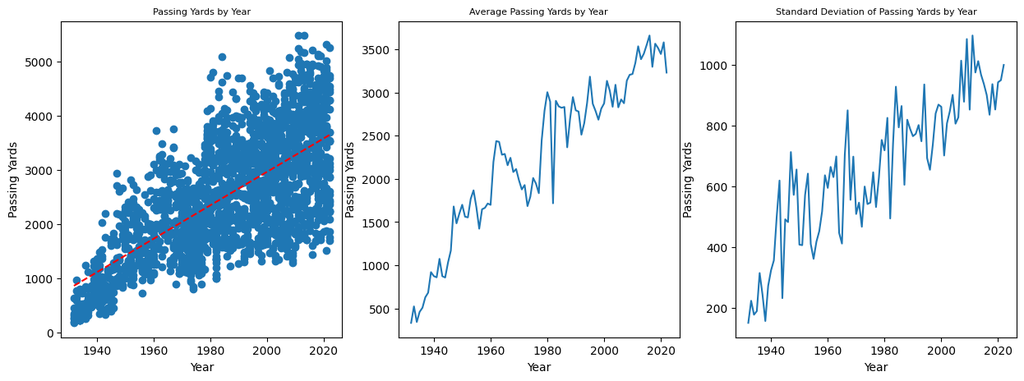

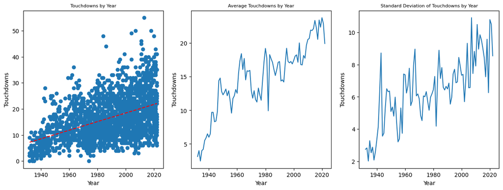

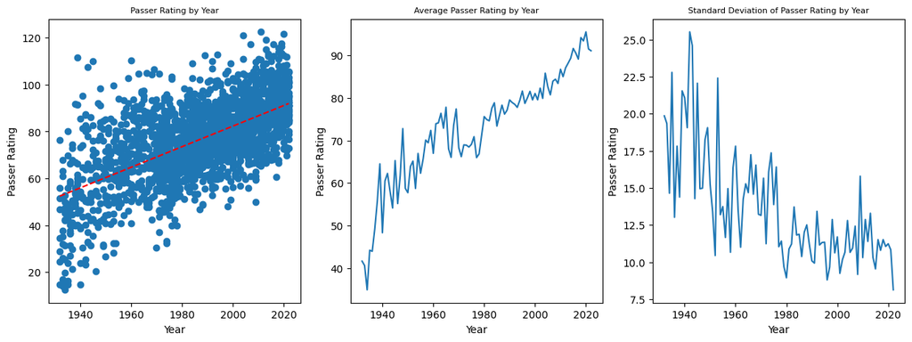

```python
make_plots(df_passing, df_passing['year'], df_passing['Yds'], 'Year', 'Passing Yards', 'year', 'Yds')
make_plots(df_passing, df_passing['year'], df_passing['TD'], 'Year', 'Touchdowns', 'year', 'TD')
make_plots(df_passing, df_passing['year'], df_passing['Rate'], 'Year', 'Passer Rating', 'year', 'Rate')
```

Let's look at quarterback rushing statistics. It appears that early on (1930s, 1940s), quarterbacks were more inclined to run. Then in the middle (1960s to 1980s) the traditional "pocket passer" was the norm. Recently it appears that the running quarterback is now becoming a more popular option again. This seems to be intriguing, we'll keep this in mind.

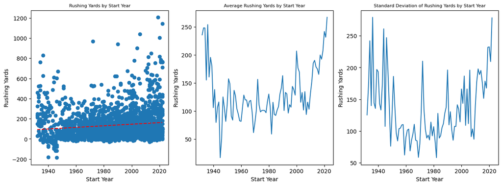

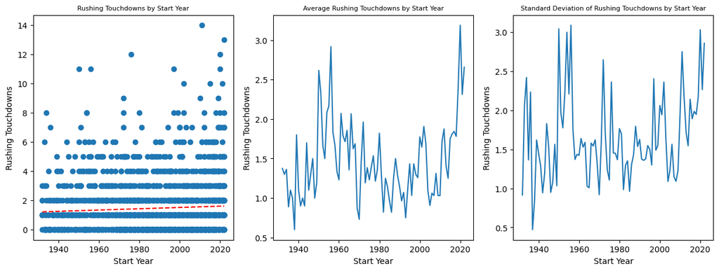

```python
make_plots(df_rushing, df_rushing['year'], df_rushing['Rush_Yds'], 'Start Year', 'Rushing Yards', 'year', 'Rush_Yds')
make_plots(df_rushing, df_rushing['year'], df_rushing['Rush_TD'], 'Start Year', 'Rushing Touchdowns', 'year', 'Rush_TD')
```

Now let's analyze some statistics with weaker correlations. Down below, it seems that quarterbacks are becoming more careful with the ball and are throwing less interceptions over time, however it's not as obvious as with the trends above. Same thing with sacks. It appears that quarterbacks are being sacked more now then before as it becomes more of a passing league, however there's no sign of increased precision as the standard deviation seems chaotic without a clear direction.

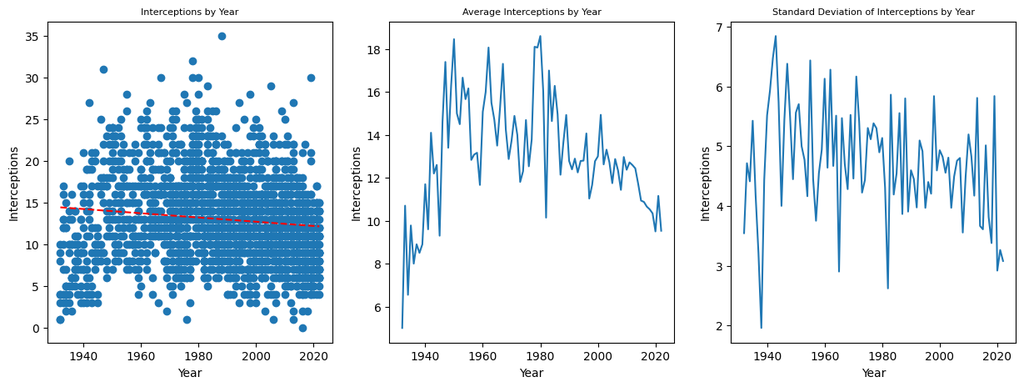

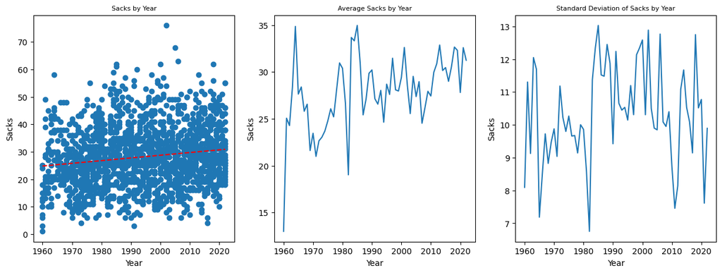

```python
make_plots(df_passing, df_passing['year'], df_passing['Int'], 'Year', 'Interceptions', 'year', 'Int')
df_temp = df_passing[df_passing['year'] >= 1960]
make_plots(df_temp, df_temp['year'], df_temp['Sk'], 'Year', 'Sacks', 'year', 'Sk')
```

Additionally, ratio statistics seem to display a stronger clustering of data as year increases, as seen by the shrinkage of the standard deviation. In all these cases (Cmp%, TD%, Int%, Sk%), standard deviation decreases over time, and three of the four statistics seem to indicate quarterbacks are improving as year increases. As year increases, quarterbacks seem to on average complete a higher percent of passes, have a lower interception percentage, and are seeming to be sacked less on a per attempt basis. The only metric that works against quarterback improvement here is a lower touchdown percentage. This may be because quarterbacks simply throw the ball more in todays game, whereas in the past passing might've been seen more as a big play, all-or-nothing move.

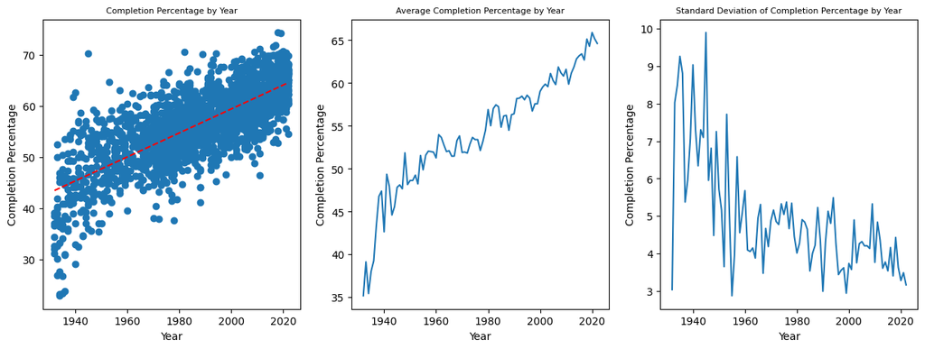

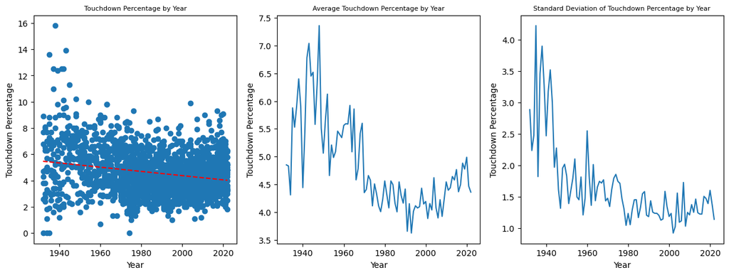

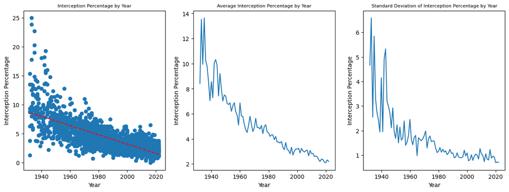

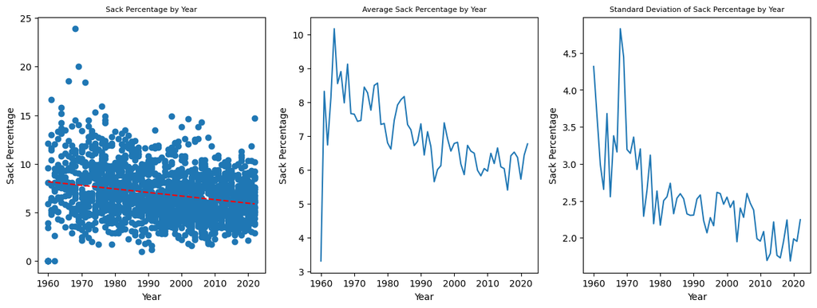

```python
make_plots(df_passing, df_passing['year'], df_passing['Cmp%'], 'Year', 'Completion Percentage', 'year', 'Cmp%')
make_plots(df_passing, df_passing['year'], df_passing['TD%'], 'Year', 'Touchdown Percentage', 'year', 'TD%')
make_plots(df_passing, df_passing['year'], df_passing['Int%'], 'Year', 'Interception Percentage', 'year', 'Int%')
df_temp = df_passing[df_passing['year'] >= 1960]
make_plots(df_temp, df_temp['year'], df_temp['Sk%'], 'Year', 'Sack Percentage', 'year', 'Sk%')
```

[figure not shown]

[figure not shown]

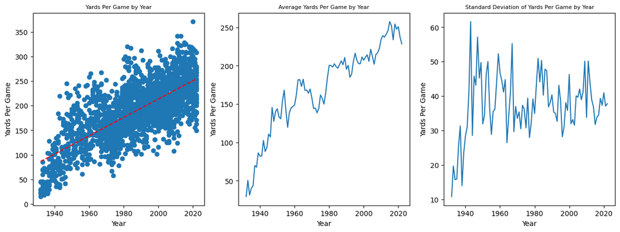

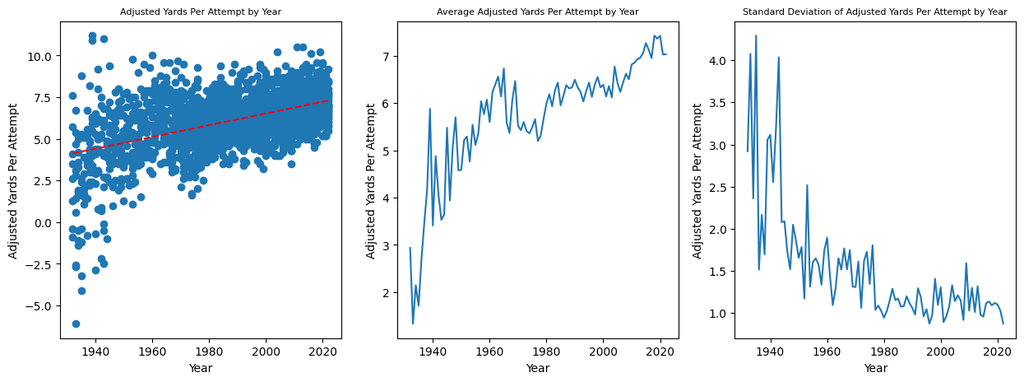

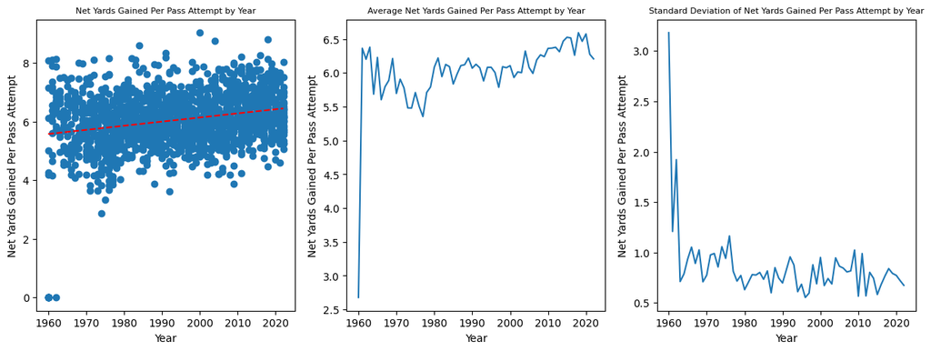

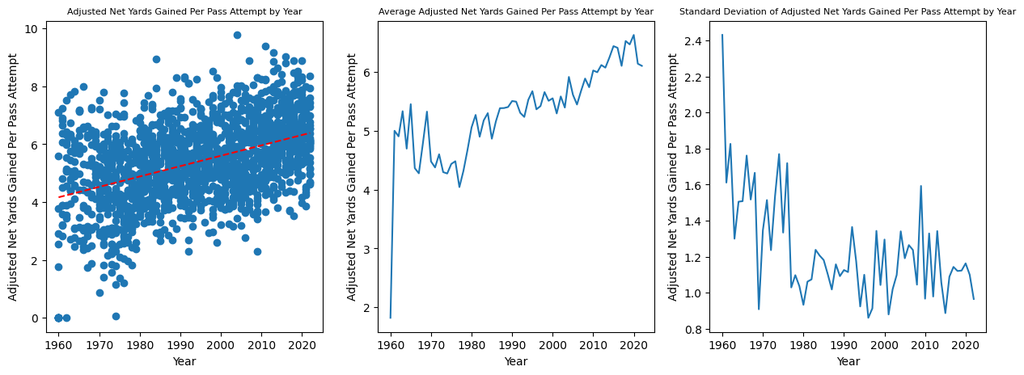

```python
make_plots(df_passing, df_passing['year'], df_passing['Y/A'], 'Year', 'Yards Per Completion', 'year', 'Y/A')
make_plots(df_passing, df_passing['year'], df_passing['Y/C'], 'Year', 'Yards Per Attempt', 'year', 'Y/C')
make_plots(df_passing, df_passing['year'], df_passing['Y/G'], 'Year', 'Yards Per Game', 'year', 'Y/G')
make_plots(df_passing, df_passing['year'], df_passing['AY/A'], 'Year', 'Adjusted Yards Per Attempt', 'year', 'AY/A')
df_temp = df_passing[df_passing['year'] >= 1960]
make_plots(df_temp, df_temp['year'], df_temp['NY/A'], 'Year', 'Net Yards Gained Per Pass Attempt', 'year', 'NY/A')
make_plots(df_temp, df_temp['year'], df_temp['ANY/A'], 'Year', 'Adjusted Net Yards Gained Per Pass Attempt', 'year', 'ANY/A')
```

Now lets take some of the variables from the plot above that showed the strongest correlation to year and analyze quarterback career statistics for those variables. We will do this by comparing quarterbacks across different decades, via box plots and bar graphs. Regarding the box plots, we can see that players that start in earlier decades are going to have less career passing yards then players starting in post-1970. Once 1970 comes, the inner quartile range remains about the same until 2000, with the median not changing much. However, the presense of outliers grows as we increase the decade. This might mean that we have more "great" quartersback as time goes on, yet the average quarterback remains the same in skill. For the decades, we only go up to the 2000s as most of the quarterbacks from that era have now retired or are out of their prime. However, the same cannot be said about the 2010s, so we exclude that era as not enough time has went by to suggest the career numbers are accurate.

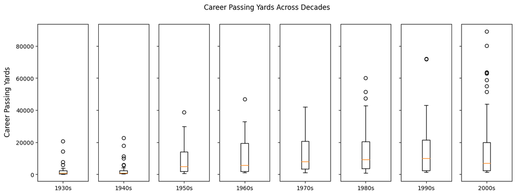

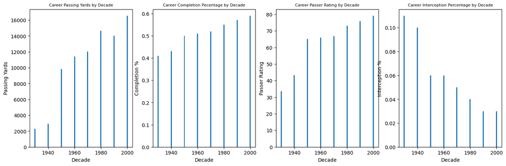

```python
# Create 8 Box Plots for Career Passing Yards, 1 per Decade
fig, axs = plt.subplots(1, 8, figsize=(15, 5), sharey=True)
fig.suptitle('Career Passing Yards Across Decades')
fig.text(0.07, 0.5, 'Career Passing Yards', va='center', rotation='vertical', fontsize=12)
axs[0].boxplot(df_1930s['Yds'])
axs[0].set_xticklabels(['1930s'])
axs[1].boxplot(df_1940s['Yds'])
axs[1].set_xticklabels(['1940s'])
axs[2].boxplot(df_1950s['Yds'])
axs[2].set_xticklabels(['1950s'])
axs[3].boxplot(df_1960s['Yds'])
axs[3].set_xticklabels(['1960s'])
axs[4].boxplot(df_1970s['Yds'])
axs[4].set_xticklabels(['1970s'])
axs[5].boxplot(df_1980s['Yds'])
axs[5].set_xticklabels(['1980s'])
axs[6].boxplot(df_1990s['Yds'])
axs[6].set_xticklabels(['1990s'])
axs[7].boxplot(df_2000s['Yds'])
axs[7].set_xticklabels(['2000s'])
plt.show()

# Create 4 Bar Graphs for Promising Statistics identified above
df_decade = df_decade[df_decade['year'] < 2010]

fig, axs = plt.subplots(1, 4, figsize=(17, 5))
axs[0].bar(df_decade['year'], df_decade['Yds'])
axs[0].set_title("Career Passing Yards by Decade", fontsize=8)
axs[0].set_xlabel('Decade')
axs[0].set_ylabel('Passing Yards')

axs[1].bar(df_decade['year'], df_decade['Cmp%'])
axs[1].set_title("Career Completion Pecentage by Decade", fontsize=8)
axs[1].set_xlabel('Decade')
axs[1].set_ylabel('Completion %')

axs[2].bar(df_decade['year'], df_decade['Rate'])
axs[2].set_title("Career Passer Rating by Decade", fontsize=8)
axs[2].set_xlabel('Decade')
axs[2].set_ylabel('Passer Rating')

axs[3].bar(df_decade['year'], df_decade['Int%'])
axs[3].set_title("Career Interception Percentage by Decade", fontsize=8)
axs[3].set_xlabel('Decade')
axs[3].set_ylabel('Interception %')
plt.show()
```

#### Model: Analysis, Hypothesis Testing, Machine Learning

Now let's make a linear regression model that will help us predict Career Passing Yards, one of the visually more significant variables that has changed over the decades. The null hypothesis in our case is the assumption that there's no relationship between our variables of our model and Passing. Let us fit an initial model just including the variable 'year', as there seems to be some correlation according to the bar plots above where Passing Yards is plotted against Decade.

```python
lr = LinearRegression()
lr = sm.ols(formula="Yds ~ year", data=players).fit()
print(lr.summary())
```

```
                            OLS Regression Results
==============================================================================
Dep. Variable:                    Yds   R-squared:                       0.061
Model:                            OLS   Adj. R-squared:                  0.059
Method:                 Least Squares   F-statistic:                     29.64
Date:                Fri, 12 May 2023   Prob (F-statistic):           8.55e-08
Time:                        23:52:10   Log-Likelihood:                -4979.2
No. Observations:                 456   AIC:                             9962.
Df Residuals:                     454   BIC:                             9971.
Df Model:                           1
Covariance Type:            nonrobust
==============================================================================
                 coef    std err          t      P>|t|      [0.025      0.975]
------------------------------------------------------------------------------
Intercept   -2.48e+05   4.76e+04     -5.205      0.000   -3.42e+05   -1.54e+05
year         130.8925     24.044      5.444      0.000      83.641     178.144
==============================================================================
Omnibus:                      211.656   Durbin-Watson:                   1.951
Prob(Omnibus):                  0.000   Jarque-Bera (JB):              938.833
Skew:                           2.081   Prob(JB):                    1.36e-204
Kurtosis:                       8.665   Cond. No.                     1.51e+05
==============================================================================

Notes:
[1] Standard Errors assume that the covariance matrix of the errors is correctly specified.
[2] The condition number is large, 1.51e+05. This might indicate that there are
strong multicollinearity or other numerical problems.
```

```python
# Remain Columns with characters that are not allowed in the formula to fit the formula
players = players.rename(columns={'Int%': 'Int_p'})
players = players.rename(columns={'Cmp%': 'Cmp_p'})
players = players.rename(columns={'Sk%': 'Sk_p'})
players = players.rename(columns={'AY/A': 'AY_A'})
players = players.rename(columns={'Y/C': 'Y_C'})
players = players.rename(columns={'Y/G': 'Y_G'})
players = players.rename(columns={'NY/A': 'NY_A'})
players = players.rename(columns={'ANY/A': 'ANY_A'})
players = players.rename(columns={'Y/A': 'Y_A'})

lr = sm.ols(formula="Yds ~ TD + Rate + Rush_TD + Rush_Yds + AY_A + Y_C + Y_G + NY_A + ANY_A + Y_A + Sk + Sk_p + Int_p", data=players).fit()
print(lr.summary())
```

```
                            OLS Regression Results
==============================================================================
Dep. Variable:                    Yds   R-squared:                       0.990
Model:                            OLS   Adj. R-squared:                  0.990
Method:                 Least Squares   F-statistic:                     3812.
Date:                Fri, 12 May 2023   Prob (F-statistic):               0.00
Time:                        23:52:10   Log-Likelihood:                -3934.1
No. Observations:                 456   AIC:                             7894.
Df Residuals:                     443   BIC:                             7948.
Df Model:                          12
Covariance Type:            nonrobust
==============================================================================
                 coef    std err          t      P>|t|      [0.025      0.975]
------------------------------------------------------------------------------
Intercept   1786.0266   1714.395      1.042      0.298   -1583.330    5155.384
TD           117.6100      1.849     63.614      0.000     113.977     121.243
Rate          -8.8967     39.253     -0.227      0.821     -86.041      68.248
Rush_TD       33.9869     16.102      2.111      0.035       2.342      65.632
Rush_Yds      -0.8250      0.166     -4.975      0.000      -1.151      -0.499
AY_A       -5214.7696    912.681     -5.714      0.000   -7008.493   -3421.046
Y_C         -121.4320    103.585     -1.172      0.242    -325.012      82.148
Y_G            0.0003      0.686      0.000      1.000      -1.347       1.348
NY_A        1.238e+04   4729.433      2.618      0.009    3085.037    2.17e+04
ANY_A       3504.9294    736.623      4.758      0.000    2057.220    4952.639
Y_A         2269.9560    381.410      5.951      0.000    1520.358    3019.554
Sk            27.0033      1.467     18.411      0.000      24.121      29.886
Sk_p        1.238e+04   4729.433      2.618      0.009    3085.037    2.17e+04
Int_p      -8.651e+04   1.46e+04     -5.914      0.000   -1.15e+05   -5.78e+04
==============================================================================
Omnibus:                       93.470   Durbin-Watson:                   1.860
Prob(Omnibus):                  0.000   Jarque-Bera (JB):             1205.020
Skew:                          -0.434   Prob(JB):                    2.15e-262
Kurtosis:                      10.916   Cond. No.                     1.18e+20
==============================================================================

Notes:
[1] Standard Errors assume that the covariance matrix of the errors is correctly specified.
[2] The smallest eigenvalue is 3.36e-32. This might indicate that there are
strong multicollinearity problems or that the design matrix is singular.
```

Here, our F-Statistic is supremely greater than the previous one (3812 > 29.64) and our p-value is 0, which is lower than the previous p-value. Thus this model appears to be a better fit. Now, let's plot the coefficients to see which ones have the largest impact on yards.

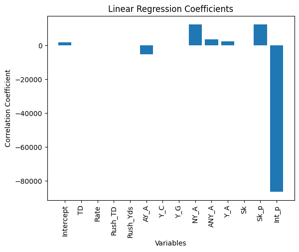

```python
# Obtain the correlation coefficients
coeffs = lr.params

# Plot the coefficients in a bar graph
plt.bar(coeffs.index, coeffs.values)

#Add labels and title
plt.xlabel('Variables')
plt.ylabel('Correlation Coefficient')
plt.title('Linear Regression Coefficients')

# Rotate x-axis labels
plt.xticks(rotation=90)

# Display the plot
plt.show()
```

It's seems that Interception Percentage as a substantial negative relationship with career passing yards. This makes sense, as quarterbacks that throw a good amount of interceptions per attempt probably won't last long as a starter (Interceptions are BAD). Let's analyze each variable more using random forest classication. This is useful for determining feature importances for each variable, which can help us further determine which variables are crucial to helping us make predictions about career passing yards using the current model.

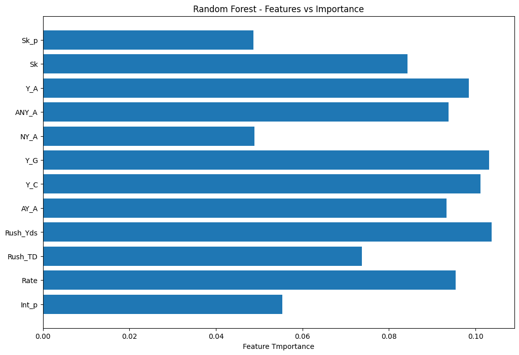

```python
df = players[['TD', 'Int_p', 'Rate', 'Rush_TD', 'Rush_Yds', 'AY_A', 'Y_C', 'Y_G', 'NY_A', 'ANY_A', 'Y_A', 'Sk', 'Sk_p', 'Yds']]

# Obtain features and yards data
X = df.values[:, 1:-1]
y = df.values[:, -1].astype(int)

# Obtain importances using Random Forest Classification
rfc = RandomForestClassifier(n_estimators=1000, criterion="gini")
rfc = rfc.fit(X, y)

# Set plot size
plt.figure(figsize=(12, 8))

# Get feature names and importances
features = df.columns[1:-1]
importances = rfc.feature_importances_

# Create horizontal bar graph
plt.barh(y=range(len(features)), width=importances)
plt.yticks(range(len(features)), features)

# set labels and title
plt.xlabel('Feature Tmportance')
plt.title('Random Forest - Features vs Importance')

# Display the plot
plt.show()
```

Here, we can see that the top three most important features are Rush_Yds, Yards per Game, and Yards per Completion. Remember these statistics are all refering to career totals. Yards per Game and Yards per Completion make sense. The higher yards per completion, the higher your yards per game are if your completion percentage is high, and the higher your yards per game are, the higher your total career passing yards are. Rush_Yds is an interesting correlation. One plausible reason for this could be that run-first quarterbacks may choose to run over pass a lot more frequently. In essence, there's less opportunities to pass, and thus a negative relationship exists between the two variables. It's very interesting the here, Interception Percentage seems to not be of such great importance. This could be because of Multicollinearity. In linear regression,we know that a variable may have a higher correlation with the target variable (Yards) but also with other independent variables. This high correlation with other independent variables might reduce its importance in a random forest classification.

#### Insight & Policy Decision

With the tutorial coming to a close, I hope you were able to see how quarterbacks have evolved over time and understand how the five stages of the data science life cycle was critical in making this realization. We have discovered various relationships among different variables and year to see how over the course of time, the careers of NFL quarterbacks are changing. Different statistics that have changed over time include passing yards, interception percentage, touchdowns, and completion percentage, just to name a few of the discoveries we made. While data collection, processing, and exploratory analysis and visualizations was crucial in seeing the evolution over time, we also discovered that there's much more to determining how a quarterback performs then just time. Other variables need to be considered as well, like the other variables mentioned above (interception percentage, completion percentage, passer rating, etc.). We can conclude that quarterbacks have gotten substantially better over time based on their better statistics. Thus, teams and coaches need to recognize the trends identified today when trying to defend against, or find the next great quarterback for themselves.